# End-to-end walkthrough

This notebook takes one method through each step: find it, check its parameters, install its environment, run it on a dataset, score its embedding and plot the scores. The method is Matilda and the dataset is `D11`: 2,864 blood cells measured with CITE-seq, which gives RNA and surface protein (ADT) for each cell.

```
find_methods → params_for → env.install → run → evaluate → plot.bubble
```

The category tutorials run several methods at once with the same `run`. Methods run on Linux. On macOS or Windows, [open this notebook in Colab](https://colab.research.google.com/github/DSichang/scMultiBench/blob/main/notebooks/tutorial_end_to_end.ipynb).

## 1. Install

This cell installs `multibench-sc`. It keeps the numpy and pandas that are already installed, so Colab needs no restart.

**Details**

On Colab, choose a GPU runtime before you run the notebook: Runtime -> Change runtime type -> T4 GPU. On a CPU runtime, an environment that has a smaller CPU build gets that build, and training methods run slower.

```python
import numpy, pandas
pins = f"numpy=={numpy.__version__} pandas=={pandas.__version__}"
%pip install -q "multibench-sc>=0.4.0" {pins}
```

## 2. Find a method

`find_methods` lists the methods that fit a category and a set of modalities. `method_info` describes one of them.

```python
import pandas as pd
import multibench as mtb

mtb.find_methods(category="vertical", modalities=["rna", "adt"])
```

```
['Multigrate',
 'totalVI',
 'scMM',
 'scMDC',
 'scMoMaT',
 'moETM',
 'Concerto',
 'Matilda',
 'VIMCCA',
 'sciPENN',
 'scMSI',
 'UINMF',
 'MOFA2',
 'Seurat_WNN']
```

```python
info = mtb.method_info("Matilda")
{k: info[k] for k in ("id", "language", "env", "gpu", "needs_labels", "reference")}
```

```
{'id': 'Matilda',
 'language': 'python',
 'env': 'matilda',
 'gpu': 'used when present',
 'needs_labels': True,
 'reference': {'doi': '10.1093/nar/gkad157',
  'title': 'Multi-task learning from multimodal single-cell omics with Matilda',
  'authors': 'Liu C, Huang H, Yang P',
  'journal': 'Nucleic Acids Research',
  'year': 2023}}
```

## 3. Get the data

`mtb.data.fetch` downloads `D11` (11 MB) once. `scan` says whether Matilda can run on it here, and why not.

**Details**

A dataset folder of your own works the same way. `mtb.io.export_dataset` writes one from an AnnData, as the category tutorials show.

```python
mtb.data.fetch("D11")
mtb.scan("D11", "vertical", methods=["Matilda"])
```

```
downloading D11 (11 MB) from https://github.com/DSichang/scMultiBench/releases/download/data-v1/D11.tar.gz ...
```

```
[scan] 1 of 1 method has its input files in D11. 0 of 1 can run on this computer. D11 holds RNA and ADT. mtb.env.install(dry_run=True) checks the environments.
```

```
[scan] Cells per file: rna.h5 2,864, adt.h5 2,864.
```

```
[scan] Matilda: Environment matilda is not installed. Run mtb.env.install(['Matilda']). mtb.env.install(category='vertical') installs the environments of every vertical method.
```

|  | method | modalities | runnable | reason | env | caveat | command |
| --- | --- | --- | --- | --- | --- | --- | --- |
| 0 | Matilda | rna+adt | False | Environment matilda is not installed. Run mtb.... | matilda | The method scripts are not in /tmp/mbtut_040/h... | conda run -n matilda python /tmp/mbtut_040/py/... |

## 4. Check the parameters

`params_for` lists the options of Matilda's script under `tunable`, with the `default` a run uses. Section 6 changes one with `params=`.

**Details**

Many methods take no parameters from the command line, and their `tunable` is empty.

The [`params_for` reference](https://dsichang.github.io/scMultiBench/reference/discover/#multibench.discover.params_for) lists the other keys.

```python
p = mtb.params_for("Matilda", "vertical", ["rna", "adt"])
{k: t["default"] for k, t in p["tunable"].items()}
```

```
{'augmentation': True,
 'batch_size': 64,
 'epochs': 30,
 'hidden_adt': 30,
 'hidden_atac': 185,
 'hidden_rna': 185,
 'lr': 0.02,
 'seed': 1,
 'z_dim': 100}
```

## 5. Install the environment

Matilda runs in its own environment. `mtb.env.install` downloads it, with no conda needed. The download is 0.6 GB on a computer without a GPU and 3.0 GB on one with a GPU.

**Details**

`state` is `PACKED` for an environment downloaded now and `have` for one that was already there. With `dry_run=True`, `mtb.env.install` downloads nothing and returns the plan with its sizes.

```python
envs = mtb.env.install(["Matilda"])
envs[["env", "methods", "state"]]
```

```
[env] downloading matilda (gpu build) 3.0 GB ...
```

```
[env]   0.3 GB of 3.0 GB (21 MB/s)
```

```
[env]   0.6 GB of 3.0 GB (18 MB/s)
```

```
[env]   0.9 GB of 3.0 GB (16 MB/s)
```

```
[env]   1.2 GB of 3.0 GB (16 MB/s)
```

```
[env]   1.5 GB of 3.0 GB (16 MB/s)
```

```
[env]   1.8 GB of 3.0 GB (16 MB/s)
```

```
[env]   connection lost (URLError); resuming
```

```
[env]   2.1 GB of 3.0 GB (11 MB/s)
```

```
[env]   2.4 GB of 3.0 GB (12 MB/s)
```

```
[env]   2.7 GB of 3.0 GB (12 MB/s)
```

```
[env]   3.0 GB of 3.0 GB (12 MB/s)
```

```
[env] unpacking matilda -> /tmp/mbtut_040/home/.cache/multibench/envs/matilda ...
```

|  | env | methods | state |
| --- | --- | --- | --- |
| 0 | matilda | [Matilda] | PACKED |

## 6. Run

`run` runs Matilda on `D11`, scores its embedding and saves the result under `out/`. `params={"Matilda": {"epochs": 10}}` shortens training for this demo. `res.embedding("Matilda")` returns the embedding as an AnnData: one row per cell, named by its barcode, with its cell type in `obs["label"]`.

**Details**

`res.summary` has the status and the scores of the run, and its `reason` column says why a method failed.

`mtb.scan("D11", "vertical", methods=["Matilda"])` returns the plan and the command without running anything. It works on any computer.

```python
res = mtb.run("D11", "vertical", methods=["Matilda"], out_dir="out/",
                  params={"Matilda": {"epochs": 10}})
emb = res.embedding("Matilda")
emb
```

```
[run] Matilda (vertical/D11) ...
```

```
Fetching the method scripts from PYangLab/scMultiBench into /tmp/mbtut_040/home/.cache/multibench/scMultiBench_ref ...
```

```
[run]   -> scored (16.1s) ARI 0.849
```

```
AnnData object with n_obs × n_vars = 2864 × 0
    obs: 'label'
    obsm: 'X_emb'
```

## 7. Score

`evaluate` scores the embedding against the cell types in `emb.obs["label"]` and returns a long table, one row per metric. `method=` and `dataset=` name the rows.

**Details**

`metrics="clustering"` computes ARI, NMI, ASW, iASW, iF1 and cLISI. D11 has a single batch, so the batch metrics do not apply.

For an embedding file, `mtb.evaluate(path, dataset="D11", category="vertical", method="Matilda")` matches the dataset's label files to the cells by the barcodes `run` writes into the file.

Scores of this run differ a little from the stored ones: most methods give a slightly different embedding on each run.

```python
scores = mtb.evaluate(emb, labels="label", method="Matilda (this run)", dataset="D11",
                      category="vertical", metrics="clustering")
scores
```

```
Clustering 2,864 cells for ARI, NMI, ASW, iASW and iF1 with the leidenalg Leiden backend.
```

|  | metric | value | method | dataset | category | source | scored_with |
| --- | --- | --- | --- | --- | --- | --- | --- |
| 0 | ARI | 0.848768 | Matilda (this run) | D11 | vertical | user | leidenalg/search/0.4.0 |
| 1 | NMI | 0.884046 | Matilda (this run) | D11 | vertical | user | leidenalg/search/0.4.0 |
| 2 | ASW | 0.638516 | Matilda (this run) | D11 | vertical | user | leidenalg/search/0.4.0 |
| 3 | iASW | 0.639074 | Matilda (this run) | D11 | vertical | user | leidenalg/search/0.4.0 |
| 4 | iF1 | 0.856217 | Matilda (this run) | D11 | vertical | user | leidenalg/search/0.4.0 |
| 5 | cLISI | 0.998403 | Matilda (this run) | D11 | vertical | user | leidenalg/search/0.4.0 |

## 8. Plot

The cell adds this run to the package's stored results of `D11` and plots them together.

**Details**

Circle size shows the rank within a column, and bigger is better. The fill compares a value with the other rows in the same column.

The stored results cover one dataset per category. Rows from your own dataset go in a figure of their own.

```python
stored = mtb.load_results("vertical", dataset="D11")
mtb.plot.bubble(pd.concat([stored, scores], ignore_index=True))
```

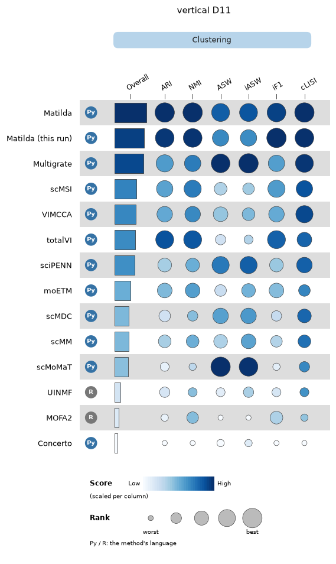

## Summary

| step | API |
| --- | --- |
| find a method | `find_methods`, `method_info` |
| get the data | `data.fetch`, `scan` |
| check the parameters | `params_for` |
| install the environment | `mtb.env.install` |
| run | `run(..., methods=[...], params={...})`, `embedding` |
| score | `evaluate` |
| plot | `load_results`, `plot.bubble` |

The category tutorials ([vertical](https://dsichang.github.io/scMultiBench/tutorials/vertical/), [diagonal](https://dsichang.github.io/scMultiBench/tutorials/diagonal/), [mosaic](https://dsichang.github.io/scMultiBench/tutorials/mosaic/), [cross](https://dsichang.github.io/scMultiBench/tutorials/cross/)) run and score several methods in one call, on the demo data and on your own.